# inferCNV分析报告

杭州广科安德生物科技有限公司

# 1 inferCNV

## 1.1 目的

inferCNV用于推断细胞的染色体拷贝数变异（CNV）情况，是目前单细胞数据鉴定恶性细胞的最经典常用的工具。

拷贝数变异（CNV）：指特定 DNA 片段的拷贝数量在不同个体基因组中有所不同。这些结构差异可能是通过重复、缺失或其他变化产生的，可能影响长段的 DNA。CNV变异是肿瘤细胞最显著的特征。

## 1.2 CNV强度热图

热图展示了不同细胞在各染色体区域的相对表达强度。图中每一行代表所属亚群的一个细胞，每一列表示对应染色体上的一个基因。红色代表扩增，蓝色代表缺失，颜色越深代表变异越显著。

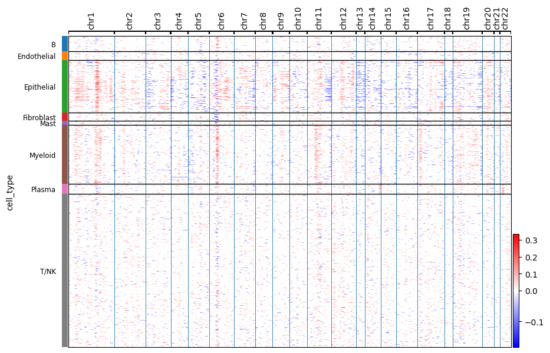

## 1.3 转录组聚类UMAP图

该图基于转录组数据的umap图，左图不同颜色代表不同的CNV聚类；中图不同颜色代表不同细胞类型；右图展示了各细胞的CNV分数，颜色越亮，CNV分数越高，恶性越强。

### 1.3.1 by cell

对每一个细胞进行CNV评分。

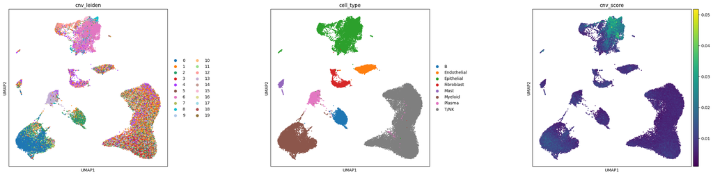

<sub>注 **左:** CNV cluster；中**:** cell type；**右:** CNV score；</sub>

### 1.3.2 by cluster

对每一个CNV聚类进行CNV评分。

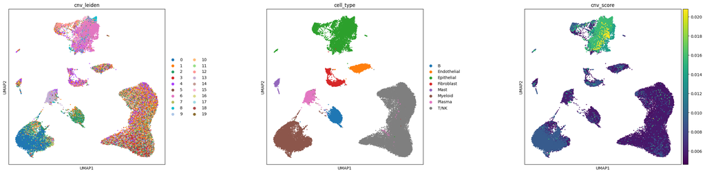

<sub>注 **左:** CNV cluster；中**:** cell type；**右:** CNV score；</sub>

## 1.4 CNV聚类UMAP图

该图基于CNV分析的umap图，左图不同颜色代表不同的CNV聚类；中图不同颜色代表不同细胞类型；右图展示了各细胞的CNV分数，颜色越亮，CNV分数越高，恶性越强。

### 1.4.1 by cell

对每一个细胞进行CNV评分。

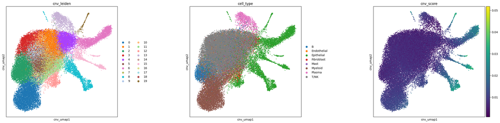

<sub>注 **左:** CNV cluster；中**:** cell type；**右:** CNV score；</sub>

### 1.4.2 by cluster

对每一个CNV聚类进行CNV评分。

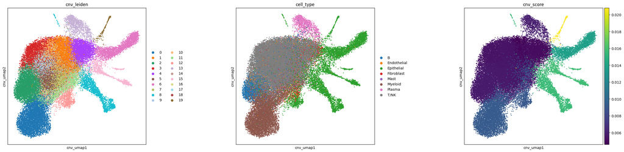

<sub>注 **左:** CNV cluster；中**:** cell type；**右:** CNV score；</sub>

## 1.5 CNV聚类提琴图

横轴代表不同的CNV cluster，纵轴代表细胞的CNV分数，每一个点代表一个细胞。通过对比不同cluster的CNV分数差异筛选出其中恶性的cluster。

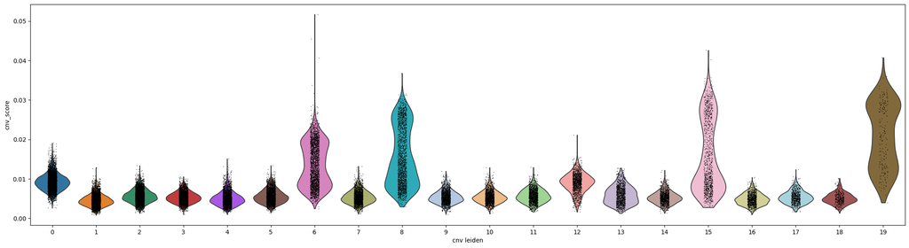

<sub>注 **横轴:** CNV cluster；**纵轴:** CNV score；</sub>

## 1.6 CNV注释UMAP图

根据CNV分数对细胞进行注释，橙色为恶性细胞，蓝色为正常细胞。

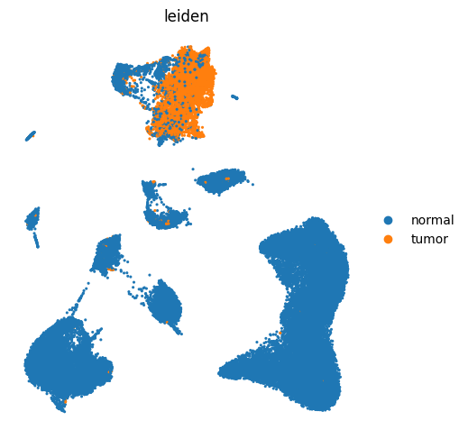

## 1.7 CNV分数表格

不同细胞的CNV聚类与CNV分数。

|  | barcode | cell_type | cnv_leiden | cnv_score_cell | cnv_score_cluster | cnv_status |
| --- | --- | --- | --- | --- | --- | --- |
| 1 | P1a_AAACGGCTCTTGAG.1 | Myeloid | 0 | 0.01047600361877332 | 0.009204849799569398 | normal |
| 2 | P1a_AAAGAGACAAAGTG.1 | Epithelial | 15 | 0.01676585425036586 | 0.01576133804874903 | tumor |
| 3 | P1a_AAAGCCTGGCGATT.1 | T/NK | 2 | 0.004271606458533999 | 0.005670311714160431 | normal |
| 4 | P1a_AAATCAACTGCCTC.1 | Epithelial | 15 | 0.009565540948134995 | 0.01576133804874903 | tumor |
| 5 | P1a_AAATCCCTCTGTAG.1 | T/NK | 18 | 0.003117612914746464 | 0.005098406850757031 | normal |
| 6 | P1a_AACAATACAAGATG.1 | Epithelial | 15 | 0.007864551217089634 | 0.01576133804874903 | tumor |
| 7 | P1a_AACATATGCTCCCA.1 | T/NK | 3 | 0.002642242524962076 | 0.005366930808167185 | normal |
| 8 | P1a_AACATATGTGAGGG.1 | Epithelial | 15 | 0.01858104542593143 | 0.01576133804874903 | tumor |
| 9 | P1a_AACATTGACCTAAG.1 | Epithelial | 15 | 0.0137125463925192 | 0.01576133804874903 | tumor |
| 10 | P1a_AACCAGTGCTTAGG.1 | Myeloid | 0 | 0.00682265441136055 | 0.009204849799569398 | normal |

[output cut: 49048 more lines]

<sub>注 barcode：细胞标签；cell_type：细胞类型定义；cnv_leiden: CNV聚类；**cnv_score_cell:** 每个细胞的CNV得分；cnv_score_cluster：每个CNV聚类的平均CNV得分；cnv_status：细胞的CNV状态</sub>